# Program 3 Report

**Team Members:** Alex Ausan, Hayden Park, Eric Van Zant

## Approach To Solving Problem

To find the longest common substring, we build a grid where each row represents a character from the first string and each column represents a character from the second string. Each cell in the grid stores the length of the longest common substring that ends at that particular pair of characters. If the two characters for a cell don't match, the cell is zero. If they do match, we look one step diagonally up and to the left and add one to whatever value is there - this extends the common substring that ended at the previous pair. By filling the grid this way from top-left to bottom-right, every cell we need is always ready before we need it. Once the grid is complete, the largest number in it tells us how long the answer is, and where in the first string it ends.

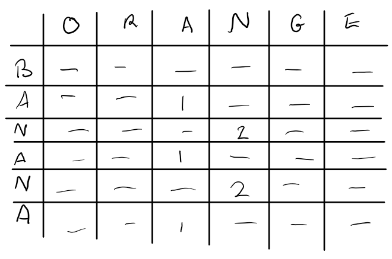

Each numbered cell marks a matching character. The matches are shown in a diagonal pattern because a common substring of length 2 or more always appears as a sequence of cells stepping down and to the right, each one building on the cell above-left of it. The longest diagonal is the answer.

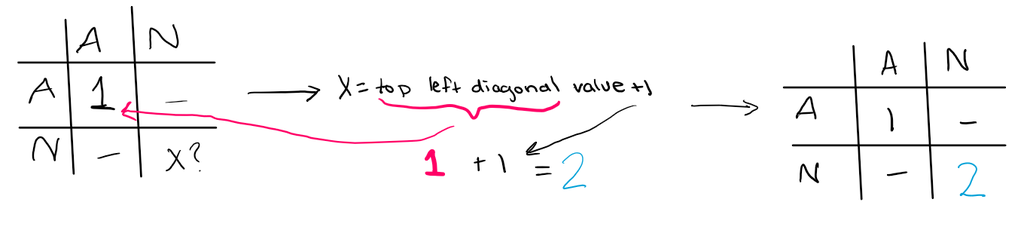

## Pseudocode

We first started by implementing the basic backtracking algorithm, which is shown below. It works by considering every possible pair of positions, one in each string, as a candidate ending point for a common substring. At each pair, it recurses backwards through both strings simultaneously, counting how many consecutive matching characters it can find before hitting a mismatch or the start of either string. The outer loop collects the longest result found across all pairs and uses it to recover the actual substring at the end.

```
function MAXIMALSUBSTRING(a, b)
   best_len <- 0
   best_end_a <- 0

    for i from 0 to |a| - 1
        for j from 0 to |b| - 1
            length <- LCS(a, b, i, j)
            if length > best_len
                best_len <- length
                best_end_a <- i
            end if
        end for
    end for
    return SLICE(a, best_end_a - best_len + 1, best_end_a + 1)
end function

function LCS(a, b, i, j)
    if i < 0 or j < 0
        return 0
    end if
    if a[i] != b[j]
        return 0
    end if
    return 1 + LCS(a, b, i - 1, j - 1)
end function
```

The next was to memoize this backtracking algorithm to make it more efficient. The backtracking approach does more than needed, because the same pair of positions can be reached and re-evaluated many times as the recursion fans out across different starting points. Memoization gets rid of this redundancy by recording each answer the first time it is computed, so that any future request for the same pair can be satisfied instantly from the cache rather than by recursing again. The overall logic of the algorithm stays exactly the same, memoization is an improvement in efficiency, not a change in strategy. The memoized pseudocode is shown below.

```
function MAXIMALSUBSTRING(a, b):
    best_len <- 0
    best_end_a <- 0
    cache <- 2D array of size |a| x |b|, initialised to EMPTY

    for i from 0 to |a| - 1:
        for j from 0 to |b| - 1:
            length <- LCS(a, b, i, j, cache)
            if length > best_len:
                best_len <- length
                best_end_a <- i
            end if
        end for
    end for

    return SLICE(a, best_end_a - best_len + 1, best_end_a + 1)
end function


function LCS(a, b, i, j, cache):
    if i < 0 or j < 0:
        return 0
    end if
    if a[i] != b[j]:
        return 0
    end if
    if cache[i][j] != EMPTY:
        return cache[i][j]
    end if
    cache[i][j] <- 1 + LCS(a, b, i - 1, j - 1, cache)
    return cache[i][j]
end function
```

The last step was to edit the algorithm so that it eagerly fills the array, and that will help us achieve a true dynamic programming algorithm. We do this by computing every answer upfront, working through all pairs in order and filling a table as we go. The recursion is gone entirely, replaced by a straightforward loop that builds the full table from scratch and reads off the best answer at the end.

```
function MAXIMALSUBSTRING(a, b):
    n <- |a|,  m <- |b|
    dp <- 2D array of size n x m, initialised to 0
    best_len <- 0
    best_end_a <- 0

    for i from 0 to n - 1:
        for j from 0 to m - 1:
            if a[i] = b[j]:
                if i = 0 or j = 0:
                    dp[i][j] <- 1
                else:
                    dp[i][j] <- 1 + dp[i-1][j-1]
                end if
            end if

            if dp[i][j] > best_len:
                best_len <- dp[i][j]
                best_end_a <- i
            end if
        end for
    end for

    return SLICE(a, best_end_a - best_len + 1, best_end_a + 1)
end function
```

## Proof of Correctness

All three algorithms rely on the same idea. Define `LCS(i, j)` as the length of the longest common substring that ends at `a[i]` and `b[j]`. If `a[i] != b[j]`, the match stops there, so `LCS(i, j) = 0`. If `a[i] == b[j]`, we can extend the matching suffix from the previous diagonal position, so `LCS(i, j) = 1 + LCS(i-1, j-1)`, with base case 0 when either index goes out of bounds. This gives the correct local value for every pair `(i, j)`.

The final answer is the maximum value of `LCS(i, j)` over all index pairs, since any common substring must end somewhere in both strings. Each algorithm checks every `(i, j)`, tracks the best length seen so far, and records where that best match ends in `a`. Returning `a[best_end_a - best_len + 1 : best_end_a + 1]` reconstructs a longest common substring. The brute-force version computes these values directly, the memoized version computes the same values while avoiding repeated work, and the dynamic programming version computes the same values in dependency order. Because all three use the same recurrence and the same max-selection step, they are correct.

## Test Cases

The table below shows a mix of normal and edge-case inputs.

| # | a | b | Expected | Brute-force Returned | Memoized Returned | DP Returned |
| --- | --- | --- | --- | --- | --- | --- |
| 1 | `ABABC` | `BABCA` | `BABC` | `BABC` | `BABC` | `BABC` |
| 2 | `HELLO` | `WORLD` | `L` | `L` | `L` | `L` |
| 3 | `XYZ` | `ABC` | `` (empty) | `` (empty) | `` (empty) | `` (empty) |
| 4 | `BANANA` | `ANANAS` | `ANANA` | `ANANA` | `ANANA` | `ANANA` |
| 5 | `AAAA` | `BAAA` | `AAA` | `AAA` | `AAA` | `AAA` |
| 6 | `` (empty) | `ABC` | `` (empty) | `` (empty) | `` (empty) | `` (empty) |

Across all six test cases, each implementation matched the expected output.

## Runtime Analysis

Let `n = |a|` and `m = |b|`.

Brute-force/backtracking: there are `n*m` outer `(i, j)` pairs. For each pair, recursion can walk backward along a matching diagonal for up to `O(min(n, m))` steps before hitting a mismatch or boundary. That gives worst-case time `O(n*m*min(n, m))`; when `n = m = k`, this is `O(k^3)`. Extra space is recursion depth `O(min(n, m))`.

Memoized recursion: each matching state `(i, j)` is computed once, then reused from cache, while non-matching calls are `O(1)`. The loops still cover `n*m` pairs, but total recursive work across unique states is `O(n*m)`. So time is `O(n*m)`, and space is `O(n*m)` for the cache plus `O(min(n, m))` recursion stack.

Dynamic programming table: each cell is filled once with constant work, so time is `O(n*m)`. Space is `O(n*m)` for the table. This matches memoization asymptotically but usually runs a bit cleaner in practice because it avoids recursion overhead.

## Benchmarking Analysis

### Process

Each function was ran 100 times at each length of n and m over generated test cases. The generated cases were produced by generating a and b then running a modified version of maximal substring which returns every acceptable substring.

### Results

#### Worse Case

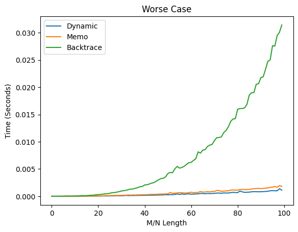

Worse case compares 2 equal strings, significantly penalizing Backtracking compared to Dynamic and memoized. As it approaches O(n*m*min(m,n)) compared to dynamic and memo staying at O(n * m)

#### Random String

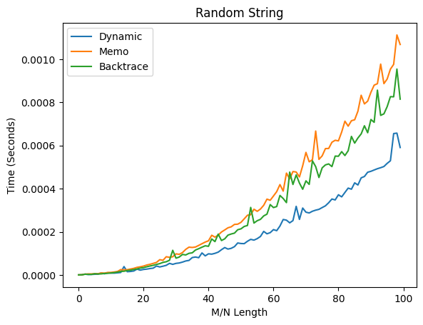

Randomly generated strings of equal length generated from the english alphabet, the shorter solution causes Backtracking to perform much better, even outperforming memoized as it has less overhead and they both are about O(n*m) as this produces very short maximal strings even against long strings.

#### Random Word Selection 20

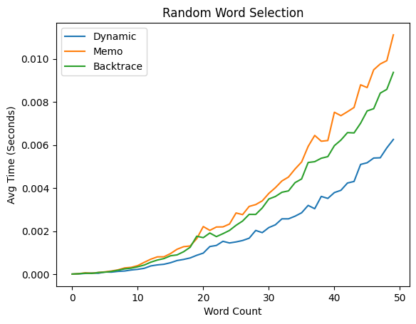

Randomly generated strings constructed from repeatedly choosing from 20 english words. This was done as random string rarely produced maximal strings longer then 3 no matter the lengths of n and m, using words made long collisions more common which should produce a middle ground between worse case and random string.

#### Random Word Selection 5

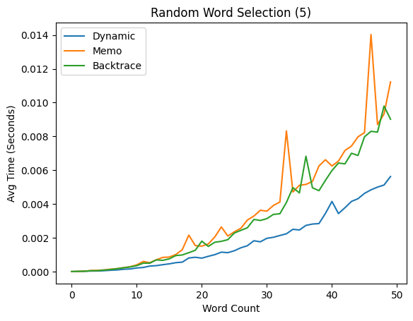

As the previous word selection showed little difference we performed it with fewer word options to better highlight the difference. This does cause memoized and backtrace to approach however even at word count of 2 the longest maximal substrings are around 10% the length of the total strings so we see little improvement.

## Appendix

### A. Source Code (Python)

```
def lcs_backtrack(a, b):
    best_len = 0
    best_end_a = 0

    def lcs(i, j):
        if i < 0 or j < 0:
            return 0
        if a[i] != b[j]:
            return 0
        return 1 + lcs(i - 1, j - 1)

    for i in range(len(a)):
        for j in range(len(b)):
            length = lcs(i, j)
            if length > best_len:
                best_len = length
                best_end_a = i

    return a[best_end_a - best_len + 1 : best_end_a + 1]


def lcs_memo(a, b):
    n, m = len(a), len(b)
    best_len = 0
    best_end_a = 0
    EMPTY = None
    cache = [[EMPTY for _ in range(m)] for _ in range(n)]

    def lcs(i, j):
        if i < 0 or j < 0:
            return 0
        if a[i] != b[j]:
            return 0
        if cache[i][j] is not EMPTY:
            return cache[i][j]
        cache[i][j] = 1 + lcs(i - 1, j - 1)
        return cache[i][j]

    for i in range(n):
        for j in range(m):
            length = lcs(i, j)
            if length > best_len:
                best_len = length
                best_end_a = i

    return a[best_end_a - best_len + 1 : best_end_a + 1]


def lcs_dp(a, b):
    n, m = len(a), len(b)
    if n == 0 or m == 0:
        return ""

    dp = [[0 for _ in range(m)] for _ in range(n)]
    best_len = 0
    best_end_a = 0

    for i in range(n):
        for j in range(m):
            if a[i] == b[j]:
                if i == 0 or j == 0:
                    dp[i][j] = 1
                else:
                    dp[i][j] = 1 + dp[i - 1][j - 1]

            if dp[i][j] > best_len:
                best_len = dp[i][j]
                best_end_a = i

    return a[best_end_a - best_len + 1 : best_end_a + 1]

def test_function(ns, ms, ans, function, name):
    for i in range(len(ns)):
        a = function(ns[i], ms[i])
        if a not in ans[i]:
            print(f"Incorrect {name}: ({ns[i]}, {ms[i]}) returned {a} instead of {ans[i]}")

    timer = time.perf_counter()
    for i in range(len(ns)):
        a = function(ns[i], ms[i])

    end = time.perf_counter()

    return (end - timer) / len(ns)

def maximalSubstringExtensive(a, b):
    max_l = 0
    max_es = None

    cache = {}

    for i in range(len(a)):
        for j in range(len(b)):
            if a[i] == b[j]:
                cache[(j,i)] = cache.get((j-1,i-1), 0) + 1
                if cache[(j,i)] > max_l:
                    max_l = cache[(j,i)]
                    max_es = set([i])
                elif cache[(j,i)] == max_l:
                    max_es.add(i)

    if max_l == 0:
        return [""]

    return [a[max_e - max_l + 1:max_e + 1] for max_e in max_es]
```

### B. Test Case Definitions

```
test_cases = [
    ("ABABC", "BABCA", "BABC"),
    ("HELLO", "WORLD", "L"),
    ("XYZ", "ABC", ""),
    ("BANANA", "ANANAS", "ANANA"),
    ("AAAA", "BAAA", "AAA"),
    ("", "ABC", "")
]
```